# Cyclistic_Case_Study:Exploratory Data Analysis (EDA) & Visualizations

### 5. Ride Volume by Rideable Type

**Code for creating the visual**

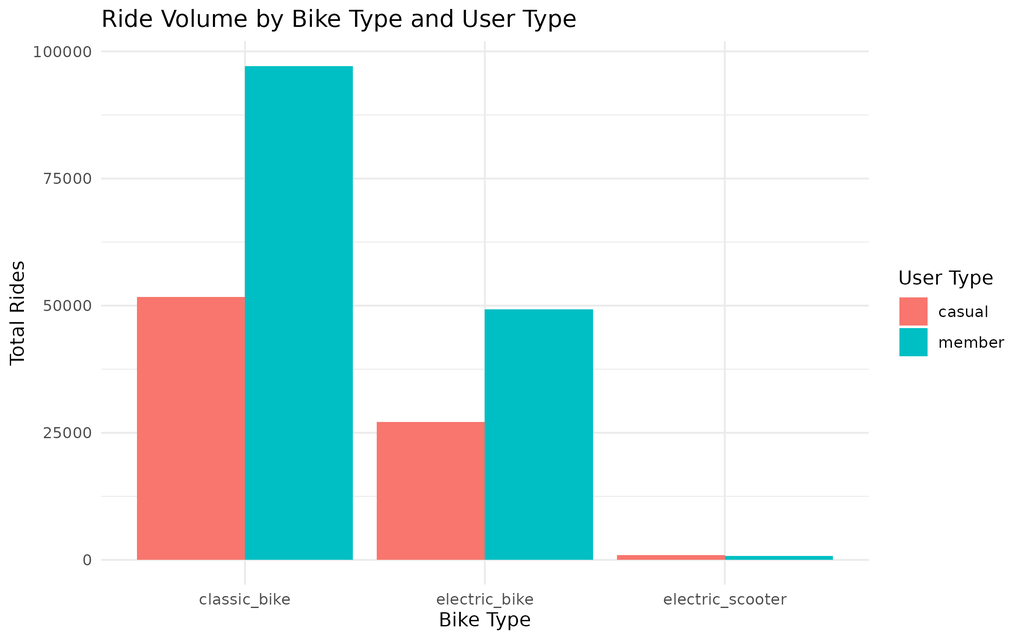

Figure 5: Preference of bike types among members and casual riders

```r
rides_by_type_plot <- ggplot(eda_rides_by_rideable_type, aes(x = rideable_type, y = total_rides, fill = member_casual)) +
  geom_bar(stat = "identity", position = position_dodge()) +
  labs(
    title = "Ride Volume by Bike Type and User Type",
    x = "Bike Type",
    y = "Total Rides",
    fill = "User Type"
  ) +
  theme_minimal()
```

**Key Conclusions:**

- Cyclistic has a significant number of rides, with “Classic bike” being the most popular rideable type across both user types. Casual vs. Member Users:
- Members are the primary riders of Classic Bikes: Member riders take almost double the number of Classic Bike rides (97,145) compared to Casual riders (51,711). This suggests Classic Bikes are a core offering for dedicated members.
- Electric bikes are popular with both groups, but more so with Members: While Casual users take a good number of Electric bike rides (27,105), Members take even more (49,297). This indicates that electric bikes appeal to a broad user base, but members utilize them more frequently.
- Electric Scooters have low usage overall: Both Casual and Member users have relatively low numbers of rides on Electric scooters (988 for Casual, 778 for Member). This suggests that electric scooters are not a primary mode of transport for either user group on Cyclistic.
- Casual users prefer electric scooters slightly more than members: While still low, Casual users have a slightly higher number of rides on Electric scooters compared to Members. Key Differences and Insights:
- Members show stronger loyalty to Classic Bikes: The much higher usage of Classic Bikes by members indicates they might be using them for longer rides, commutes, or as their preferred mode for regular trips.
- Casual users might be exploring different options: The higher proportion of Classic Bike and Electric Bike usage for Casual users, relative to Electric Scooters, suggests they might be trying out the more “traditional” bike options.
- Opportunity for Electric Scooter promotion: Given the low usage, Cyclistic might consider promotions or educational campaigns to encourage more users, especially members, to try electric scooters if they want to boost ridership for that rideable type.
- Classic Bikes are a strong asset: The high demand for Classic Bikes, especially among members, highlights their importance to Cyclistic’s business model.